# Analyzing Legislative Burden Upon Businesses Using NLP and ML

## Background

- Collaboration between Bardess and Government of Ontario
- Leverage NLP techniques to analyse patterns in the law that can be used to better understand it, extract information that is relevant to the public, create links with other legal and non legal documents

#### Focus for this workshop:

- Analyse the [Accessibility for Ontarians with Disability Act (AODA)](https://www.ontario.ca/laws/statute/05a11#BK11) and its [regulation](https://www.ontario.ca/laws/regulation/110191/v5):
  - Passed in 2005
  - Process for developing and enforcing accessibility standards in Ontario
- Identify and analyse burdens imposed upon businesses and government
  - A burden is a requirement or obligation that organizations have to comply with.
  - Physical, architectural, reporting, training etc.

### https://github.com/bardess/odsc_2019_workshop

## Spacy

- [spacy.io](https://spacy.io/)
- Written in Python and Cython
- Pre-trained neural networks models for English, German, Spanish, Portuguese, French, Italian and Dutch
- Multi-language models

### Comparison with nltk

- Performance and production focused VS teaching and research
- Less functionalities
- Faster

Full comparison and details on accuracy and speed [here](https://spacy.io/usage/facts-figures#other-libraries)

### Functionalities

- Sentence and word tokenization
- Lemmatization
- Named Entity Recognition (NER)
- Parts Of Speech (POS) tagging
- Sependencing Parsing (DP)

### Usage

```python
import spacy
from spacy import displacy
```

```python
nlp = spacy.load('en')
```

```python
parsed = nlp('''The ramp must have a minimum clear width of 900 mm''')
```

#### Tokenization, Normalization, Lemmatization

- Sentence and word tokenization

```python
list(parsed.sents)
```

```
[The ramp must have a minimum clear width of 900 mm]
```

```python
for token in parsed:
    print('"{0}"'.format(token.text), token.norm_, token.lemma_, token.is_stop, token.is_alpha)
```

```
"The" the the False True
"ramp" ramp ramp False True
"must" must must True True
"have" have have True True
"a" gonna a True True
"minimum" minimum minimum False True
"clear" clear clear False True
"width" width width False True
"of" of of True True
"900" 900 900 False False
"mm" mm mm False True
```

#### Named Entity Recognition (NER)

- Locate and classify named entity mentions in unstructured text into pre-defined categories such as the person names, organizations, locations, dates etc.

```python
parsed.ents
```

```
(900,)
```

```python
displacy.render(parsed, style='ent', jupyter=True)
```

The ramp must have a minimum clear width of 900 CARDINAL mm

#### Parts of Speech Taggings and Dependency Parsing

- Parts Of Speech tagging: assign words with similar grammatical properties to the same tag/category
- Dependencing Parsing: builds a tree representing the grammatical relashionships between words in the sentence

```python
for token in parsed:
    print('"{}"'.format(token.text), token.pos_, token.dep_)
```

```
"The" DET det
"ramp" NOUN nsubj
"must" VERB aux
"have" VERB ROOT
"a" DET det
"minimum" ADJ amod
"clear" ADJ amod
"width" NOUN dobj
"of" ADP prep
"900" NUM nummod
"mm" NOUN pobj
```

```python
displacy.render(parsed, style='dep', jupyter=True)
```

[figure not shown]

### A little grammar

`subject`:

- The word or phrase that indicates "who" or "what" performs the action
- Entities that are responsible for complying with the burdens/obligations

**Every employer** shall provide individualized workplace emergency response information to employees who have a disability

`object`:

- The entity that is acted upon by the subject
- The burden specification

Every employer shall **provide individualized workplace emergency response information** to employees who have a disability

## Identifying Burdens

- The structure of legal texts is relatively rigid and the lexicon is limited
- Rule based extraction based on a lightweight ontology

```python
BURDENS = ['shall', 'must', 'ought', 'oblige', 'require']
```

**WordNet®** is a large lexical database of English. Nouns, verbs, adjectives and adverbs are grouped into sets of cognitive synonyms (synsets), each expressing a distinct concept. Synsets are interlinked by means of conceptual-semantic and lexical relations. The resulting network of meaningfully related words and concepts can be navigated with the [browser](http://wordnetweb.princeton.edu/perl/webwn). WordNet is also freely and publicly available for download.

```python
from nltk.corpus import wordnet
```

```python
wordnet.synsets('require')
```

```
[Synset('necessitate.v.01'),
 Synset('ask.v.04'),
 Synset('command.v.02'),
 Synset('want.v.02')]
```

```python
synonyms = []

for w in BURDENS:
    for syn in wordnet.synsets(w, pos='v'):
        for l in syn.lemmas():
            synonyms.append(l.name())
```

```python
print(synonyms)
```

```
['compel', 'oblige', 'obligate', 'oblige', 'bind', 'hold', 'obligate', 'oblige', 'accommodate', 'necessitate', 'ask', 'postulate', 'need', 'require', 'take', 'involve', 'call_for', 'demand', 'ask', 'require', 'expect', 'command', 'require', 'want', 'need', 'require']
```

The list of verbs in `BURDENS` and `synonyms` define a lightweight ontology, that is used to idenlify the obligations prescribed by AODA. Given a sentence:

- Extract lemma from each term
- If any of the lemmas appears in the ontology, add the sentence to the list of burdens

```python
aoda[['index','Title', 'section', 'text']].head()
```

|  | index | Title | section | text |
| --- | --- | --- | --- | --- |
| 0 | 0 | INTERPRETATION | AODA Purpose | Recognizing the history of discrimination agai... |
| 1 | 1 | INTERPRETATION | AODA Definitions | In this Act, “accessibility standard” means an... |
| 2 | 2 | INTERPRETATION | AODA Definitions | ”) “barrier” means anything that prevents a pe... |
| 3 | 3 | INTERPRETATION | AODA Definitions | (“directeur”) “disability” means, any degree o... |
| 4 | 4 | INTERPRETATION | AODA Definitions | “Minister” means the Minister of Citizenship a... |

```python
aoda['tagged_as_burden'] = aoda.text\
    .map(lambda sent: any([True for token in nlp(sent) if token.lemma_ in BURDENS + synonyms]))
```

### Evaluation

```python
aoda['tagged_as_burden'].sum()
```

```
543
```

- Accuracy

```python
(aoda.is_burden == aoda.tagged_as_burden.astype(int)).sum()/len(aoda)
```

```
0.8909090909090909
```

[figure not shown]

```python
TP / (TP + FP)
```

```
0.7661141804788214
```

```python
aoda.iloc[17]['text']
```

```
'An accessibility standard shall name or describe the persons or organizations to which it applies.'
```

[figure not shown]

```python
TP / (TP + FN)
```

```
0.9742388758782201
```

```python
aoda.iloc[33]['text']
```

```
'The Minister is responsible for establishing and overseeing a process to develop and implement all accessibility standards necessary to achieving the purposes of this Act.'
```

## Identify the subjects of the burdens

**Objective**

- Extract the subjects of the burdens
- Organize burdens into homogeneous groups based on the entities they affect, e.g. public VS private

Dependency parsing tags for sentence subjects: `nsubj`, `nsubjpass`, `csubj`, `csubjpass`, `agent`, `expl`

```python
parsed = nlp('''Obligated organizations that are school boards or educational or training institutions shall keep a record of the training provided.''')
```

**Obligated organizations that are school boards or educational or training institutions** shall keep a record of the training provided

Obligated **organizations** that are school boards or educational or training institutions shall keep a record of the training provided.

```python
displacy.render(parsed, style='dep', jupyter=True)
```

[figure not shown]

#### Solution

- Combine tags assigned by the Dependency Parser with Breadth First Search
- Navigate the dependency tree and identify the subset of token that are related to the subject by a parent-child relationship

```python
from utils import make_sentence, STOPWORDS
```

```python
df = pd.DataFrame(
        list(
            aoda[aoda.tagged_as_burden][['index', 'section', 'text', 'Title']]\
                .apply(lambda row: make_sentence(row['index'], nlp(row['text']), row['section'], row['Title']),
                       axis=1)
    )
)
```

```python
df.head(1)
```

|  | sid | section | title | text | subj | v | obj |
| --- | --- | --- | --- | --- | --- | --- | --- |
| 0 | 3 | AODA Definitions | INTERPRETATION | (“directeur”) “disability” means, any degree o... | ( “ directeur ” ) “ disability ” that by bodil... | [] | the generality of the foregoing diabetes melli... |

- Normalize
- Project subjects into a semantic space ([GloVe](https://nlp.stanford.edu/projects/glove/))
- Reduce dimensionality
- KMeans clustering
- Normalization

```python
df['s_norm'] = df.subj.apply(
    lambda subj: [t.lemma_ for t in nlp(subj) if t.is_alpha and t.lemma_ not in STOPWORDS]
)
```

- Projection into GloVe space

```python
glove50 = spacy.load('/tmp/vectors')
```

```python
df = pd.concat([
    df,
    pd.DataFrame(df.s_norm.map(glove_projection).tolist(),
                 columns=['s{}'.format(i) for i in range(50)])
], axis=1)
```

```python
df.head(1)
```

|  | sid | section | title | text | subj | v | obj | s_norm | s0 | s1 | ... | s40 | s41 | s42 | s43 | s44 | s45 | s46 | s47 | s48 | s49 |
| --- | --- | --- | --- | --- | --- | --- | --- | --- | --- | --- | --- | --- | --- | --- | --- | --- | --- | --- | --- | --- | --- |
| 0 | 3 | AODA Definitions | INTERPRETATION | (“directeur”) “disability” means, any degree o... | ( “ directeur ” ) “ disability ” that by bodil... | [] | the generality of the foregoing diabetes melli... | [directeur, disability, bodily, injury, benefit] | 0.262835 | 0.235594 | ... | -0.016954 | -0.317374 | -0.123995 | 0.770236 | -0.090187 | -0.600568 | -0.100497 | 0.311346 | 0.577616 | 0.208082 |

1 rows × 58 columns

### Dimensionality Reduction (Spectral Embeddings)

- Non linear embeddings
- Laplacian Eigenmaps: find a low dimensional representation of the data using a spectral decomposition of the Graph Laplacian
- Points that are close to each other on the manifold are mapped close to each other in the low dimensional space
- Local distances are preserved

```python
from sklearn.cluster import KMeans
from sklearn.manifold import SpectralEmbedding
```

```python
n_dim = 2
embeddings = SpectralEmbedding(n_components=n_dim)
```

```python
subjects = pd.DataFrame(
    embeddings.fit_transform(df[['s{}'.format(i) for i in range(50)]]),
    columns=['x{}'.format(i) for i in range(n_dim)])
```

### KMeans

```python
inertia = []
for k in range(1, 10):
    km = KMeans(n_clusters=k).fit(subjects)
    inertia.append(km.inertia_)
```

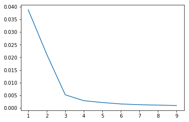

```python
sns.lineplot(x=range(1, 10), y=inertia)
```

```python
km = KMeans(n_clusters=3, random_state=0).fit(subjects)
```

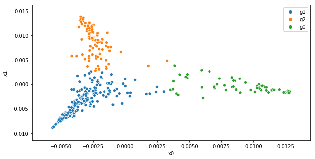

```python
plt.figure(figsize=(10,5))
sns.scatterplot(data=subjects, x='x0', y='x1', hue=['g{}'.format(label) for label in km.labels_])
```

### Visualizing the Groups

- Distribution of word frequencies in the groups

```python
counter = CountVectorizer(tokenizer=LemmaTokenizer())
counter.fit(df.subj)

# transform sentences using CountVectorizer
subj = pd.DataFrame(
    counter.fit_transform(df['subj'].astype(str)).toarray(),
    columns=counter.get_feature_names()
)

# add groups labels
subj['label'] = km.labels_

# aggregate frequences at group level
groups = pd.melt(
    subj.groupby('label').sum().reset_index(),
    id_vars='label', var_name='word', value_name='count'
).groupby('label').apply(lambda group: group.sort_values(by='count', ascending=False)).reset_index(drop=True)

# rank by frequency
groups['rank'] = groups.groupby('label')['count'].rank(method='first', ascending=False)
```

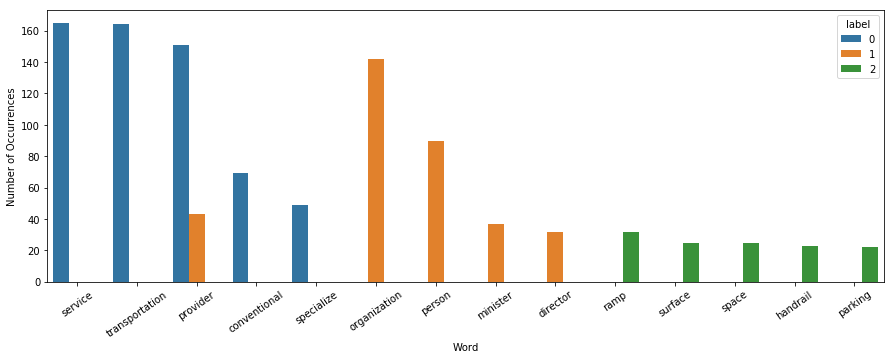

```python
plt.figure(figsize=(15,5))
sns.barplot(data=groups[groups['rank'] <= 5], x='word', y='count', hue='label')
plt.xticks(rotation=35)
plt.xlabel('Word')
plt.ylabel('Number of Occurrences')
plt.show();
```

### Group 0

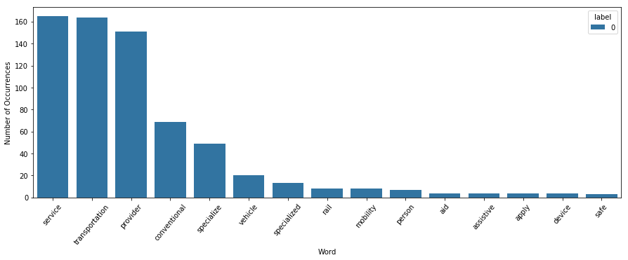

```python
vocab_barplot(groups, label=0, max_rank=15)
```

```python
(km.labels_ == 0).sum() / len(km.labels_)
```

```
0.21178637200736647
```

```python
pd.DataFrame(df[km.labels_ == 0]['title'].value_counts() / (km.labels_ == 0).sum())
```

|  | title |
| --- | --- |
| TRANSPORTATION STANDARDS | 0.921739 |
| DESIGN OF PUBLIC SPACES STANDARDS (ACCESSIBILITY STANDARDS FOR THE BUILT ENVIRONMENT) | 0.069565 |
| GENERAL | 0.008696 |

### Group 1

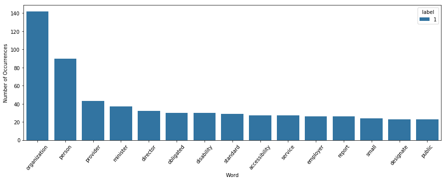

```python
vocab_barplot(groups, label=1, max_rank=15)
```

```python
(km.labels_ == 1).sum() / len(km.labels_)
```

```
0.5340699815837937
```

```python
pd.DataFrame(df[km.labels_ == 1]['title'].value_counts() / (km.labels_ == 1).sum())
```

|  | title |
| --- | --- |
| DESIGN OF PUBLIC SPACES STANDARDS (ACCESSIBILITY STANDARDS FOR THE BUILT ENVIRONMENT) | 0.206897 |
| GENERAL | 0.131034 |
| TRANSPORTATION STANDARDS | 0.124138 |
| INFORMATION AND COMMUNICATIONS STANDARDS | 0.117241 |
| ACCESSIBILITY STANDARDS | 0.093103 |
| EMPLOYMENT STANDARDS | 0.082759 |
| COMPLIANCE | 0.068966 |
| INSPECTIONS | 0.041379 |
| DIRECTOR’S ORDERS AND ADMINISTRATIVE PENALTIES | 0.037931 |
| APPEALS TO TRIBUNAL | 0.031034 |
| ADMINISTRATION | 0.020690 |
| INCENTIVE AGREEMENTS | 0.017241 |
| MUNICIPAL ACCESSIBILITY ADVISORY COMMITTEES | 0.017241 |
| INTERPRETATION | 0.006897 |
| APPLICATION | 0.003448 |

### Group 2

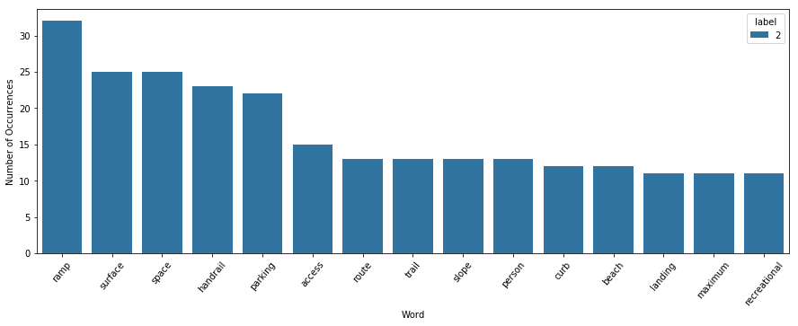

```python
vocab_barplot(groups, label=2, max_rank=15)
```

```python
(km.labels_ == 2).sum() / len(km.labels_)
```

```
0.2541436464088398
```

```python
pd.DataFrame(df[km.labels_ == 2]['title'].value_counts() / (km.labels_ == 2).sum())
```

|  | title |
| --- | --- |
| DESIGN OF PUBLIC SPACES STANDARDS (ACCESSIBILITY STANDARDS FOR THE BUILT ENVIRONMENT) | 0.804348 |
| TRANSPORTATION STANDARDS | 0.137681 |
| ACCESSIBILITY STANDARDS | 0.014493 |
| COMPLIANCE | 0.014493 |
| DIRECTOR’S ORDERS AND ADMINISTRATIVE PENALTIES | 0.014493 |
| ADMINISTRATION | 0.007246 |
| EMPLOYMENT STANDARDS | 0.007246 |

### Conclusions

- AODA has a significant section dedicated to transportation services
- Many references to architectural and physical requirements
- Hard to split beween responsibilities that fall on the Governement and its agencies and responsibilities that fall on businesses

## Topic Analysis

- Latent Dirichlet Allocation
- Generative probabilistic model that explains how the words have been assigned to documents/sentences
- Latent variables explain regularieties in the text (topics)

```python
from sklearn.pipeline import Pipeline
from sklearn.decomposition import LatentDirichletAllocation
```

```python
n_topics = 3

pipeline = Pipeline([
    ('counts', CountVectorizer(max_features=50, tokenizer=LemmaTokenizer())),
    ('lda', LatentDirichletAllocation(n_components=n_topics, learning_decay=0.5, max_iter=10, random_state=1))
])
```

```python
pipeline.fit(df.subj)
```

```
Pipeline(memory=None,
     steps=[('counts', CountVectorizer(analyzer='word', binary=False, decode_error='strict',
        dtype=<class 'numpy.int64'>, encoding='utf-8', input='content',
        lowercase=True, max_df=1.0, max_features=50, min_df=1,
        ngram_range=(1, 1), preprocessor=None, stop_words=None,
        strip...           random_state=1, topic_word_prior=None,
             total_samples=1000000.0, verbose=0))])
```

```python
import pyLDAvis
import pyLDAvis.sklearn
pyLDAvis.enable_notebook()
```

```python
vectorizer = pipeline.named_steps['counts']
dtm = vectorizer.fit_transform(df.subj)
```

```python
p = pyLDAvis.sklearn.prepare(pipeline.named_steps['lda'], dtm, vectorizer)
pyLDAvis.display(p)
```

### Follow up

- Preprocessing, e.g. extend the list of stopwords to include words like organizations
- Analyse the objects of the sentences

### https://github.com/bardess/odsc_2019_workshop